# Data Exploration

1. Introduction
   1. Objective
2. Analysis and Findings
   1. Data Description
   2. Importing Data
   3. Data Preparation
   4. Exploration
      1. How has the average temperature changed over the years globally?
      2. How does temperature change as an indicator of climate change vary in OECD Countries before and after Covid-19 i.e., in 2020 and after 2016 but before 2020?
      3. What is the overall seasonal variation of temperature around the world?
      4. Are there any noticeable differences in temperature trends between developed and developing countries?
      5. How does temperature change vary between different continents
      6. What are the temperature variations in different regions of Africa in the last 2 decades?
      7. Which countries or regions have experienced the fastest temperature increase in the past 10 years?
3. Recommendations
4. Conclusion
5. References

### 1. Introduction

Global temperature serves as a widely used measure to represent the overall condition of the Earth's climate. Although the impacts of climate change are experienced on a local scale, climate models indicate that various global climate forcings tend to produce relatively consistent effects across the globe (Hansen, et al., 2005). Over the last century, the Earth's temperature has risen by approximately 0.9–1 °C, whereas the Arctic region has undergone a more significant warming of 2–3 °C during the same period (IPCC, 2018, 2021). Based on the latest forecasts, if the current rate of temperature increase persists, global warming is projected to reach 1.5 °C by 2030 (IPCC, 2021).

##### Temperature as an indicator of climate change

Many studies have been conducted which indicate that climate change may have contributed to the occurrences of extreme floods, heat waves, droughts, ocean warming, coral reef bleaching, sea level rise, altered precipitation patterns, increased fire activity, more frequent and severe storms, as well as changes in species' physiology, phenology, and distribution (Rahmstorf & Coumou, 2011). For instance, during the summer of 2013, a severe heat wave struck Australia, subjecting most parts of the continent to prolonged extreme temperatures. People often speculate about whether each year is the warmest or coldest on record. To quantify global temperature changes, multiple studies have been conducted, primarily relying on data from meteorological stations (Brohan, et al., 2006; Hansen, et al., 2010; Rahmstorf & Coumou, 2011).

As observed, the effect of high temperatures range from environmental, social, to economic highlighting the importance of understanding the current state of climate affairs as a precursor to developing and adopting techniques suitable for combating any resultant effects.

#### Objective

The objective of the current study is to examine various aspects of climate change across the world based on temperature changes recorded between 1961 and 2020. In Particular, the current study will examine the following questions related to temperature change:

#### How does temperature change as an indicator of climate change vary in OECD Countries before and after Covid-19 i.e., in 2020 and after 2016 but before 2020?

A report by (OECD, 2023) shows that emissions of OECD countries reached their highest point in 2007, followed by a gradual decline until 2016, resulting in a decrease of 9%. Subsequently, emissions remained relatively stable during the period of 2017 to 2019. However, in 2020, emissions experienced a notable 7% drop due to the impact of the COVID-19 pandemic and the subsequent reduction in human activities. Despite this reduction, emissions rebounded in 2021, as reported by the International Energy Agency (IEA, 2021). By examining temperature deviations over time across the two periods, we can identify whether the rate of temperature change in OECD countries is linked to carbon emissions.

#### How has the average temperature changed over the years for globally?

This question helps identify long-term trends and patterns in temperature variations across different regions, enabling us to understand the implications of climate change on a global scale.

#### What is the overall seasonal variation of temperature around the world?

Seasonal patterns have been noted in areas such as Finland where there are different climatic zones, spanning from temperate in the southern regions to continental/subarctic in the east, and maritime/subarctic in the west and north. This leads to pronounced seasonal variations and considerable spatial diversity (Kortelainen and Karhu, 2004). This question explores the cyclic patterns in temperature for each year, helping to understand the seasonal variations and possibly identifying any shifts in the timing of seasons over time.

#### Are there any noticeable differences in temperature trends between developed and developing countries?

The IPCC's Fifth Assessment Report (AR5), published in 2014, extensively examined the uneven impacts of climate change on different regions and countries, with a specific focus on the disparities between developed and developing nations (IPCC 2014). According to the report, countries, particularly those in the tropics and low-lying coastal areas, are more vulnerable to the adverse effects of climate change, including rising temperatures, sea-level rise, extreme weather events, and changing precipitation patterns.

By comparing the temperature trends of Annex I (developed) and Non-Annex I (developing) countries, we can explore if there are disparities in temperature changes and assess their potential impacts on different economies.

#### How has the average temperature across different continents over the past two decades?

A recent climate report indicates that Europe is experiencing warming at a rate twice as fast as the global average (Serreze & Francis, 2006; Serreze, Barrett, Stroeve, & Kindig, 2009; England, Eisenman, Lutsko, & Wagner, 2021). The year 2022 witnessed extreme heat, drought, and wildfires that swept across the continent. By examining differences in average temperature change between different continents, we can establish which continent is at the highest risk of experiencing adverse climate effects due to temperature increases.

#### What are the temperature variations in different regions of Africa?

Between 1991 and 2021, Africa experienced a faster warming rate of approximately +0.3 °C per decade, compared to the +0.2°C per decade warming observed from 1961 to 1990 (World Meteorological Organization, 2022). The year 2021 ranked as either the third or fourth warmest year on record for the continent. West Africa has been identified as a climate-change hotspot, where the effects of climate change are expected to reduce crop yields and production, potentially leading to significant impacts on food security (Shepard, 2019). It is also expected that South Africa will be affected with it becoming drier, with an increase in both drought frequency and the occurrence of heat waves as we approach the end of the 21st century. Investigating temperature patterns in different African regions can help in understanding the challenges faced by this continent due to its diverse climate zones and the potential impacts on agriculture and ecosystems.

#### Which countries or regions have experienced the fastest temperature increase in the past 10 years?

Identifying the regions with the most rapid temperature rise can aid in prioritizing climate action and adaptation efforts for areas facing immediate challenges.

### Analysis and Findings

#### Data Description

Data used in this study contained information related to statistics on the average surface temperature change by country, updated annually, for the period 1961 to 2019. The statistics include monthly, seasonal, and annual mean temperature anomalies, which represent the deviation of temperature from a baseline climatology ranging from 1951 to 1980. Additionally, the dataset includes the standard deviation of temperature change based on the baseline methodology. The data is sourced from the publicly available GISTEMP data, specifically the Global Surface Temperature Change data distributed by NASA's Goddard Institute for Space Studies (NASA-GISS). The data can be accessed from the following link https://www.kaggle.com/datasets/sevgisarac/temperature-change?group=bookmarked

##### Import Data

```python
#to work around some deprecations in trend test
#!pip install "numpy<1.24" --user
#!pip install pymannkendall
```

```python
import pandas as pd
import numpy as np
import seaborn as sns
import plotly.express as px
import plotly.graph_objects as go
import matplotlib.pyplot as plt
import statsmodels.api as sm
from statsmodels.tsa.seasonal import seasonal_decompose
import warnings
warnings.filterwarnings('ignore')
```

```python
import os
os.listdir('data')
```

```
['Environment_Temperature_change_E_All_Data_NOFLAG.csv',
 'FAOSTAT_data_1-10-2022.csv',
 'FAOSTAT_data_11-24-2020.csv']
```

```python
data = pd.read_csv("data/Environment_Temperature_change_E_All_Data_NOFLAG.csv", encoding = 'ISO-8859-1')
#data overview
data.head()
```

|  | Area Code | Area | Months Code | Months | Element Code | Element | Unit | Y1961 | Y1962 | Y1963 | ... | Y2010 | Y2011 | Y2012 | Y2013 | Y2014 | Y2015 | Y2016 | Y2017 | Y2018 | Y2019 |
| --- | --- | --- | --- | --- | --- | --- | --- | --- | --- | --- | --- | --- | --- | --- | --- | --- | --- | --- | --- | --- | --- |
| 0 | 2 | Afghanistan | 7001 | January | 7271 | Temperature change | °C | 0.777 | 0.062 | 2.744 | ... | 3.601 | 1.179 | -0.583 | 1.233 | 1.755 | 1.943 | 3.416 | 1.201 | 1.996 | 2.951 |
| 1 | 2 | Afghanistan | 7001 | January | 6078 | Standard Deviation | °C | 1.950 | 1.950 | 1.950 | ... | 1.950 | 1.950 | 1.950 | 1.950 | 1.950 | 1.950 | 1.950 | 1.950 | 1.950 | 1.950 |
| 2 | 2 | Afghanistan | 7002 | February | 7271 | Temperature change | °C | -1.743 | 2.465 | 3.919 | ... | 1.212 | 0.321 | -3.201 | 1.494 | -3.187 | 2.699 | 2.251 | -0.323 | 2.705 | 0.086 |
| 3 | 2 | Afghanistan | 7002 | February | 6078 | Standard Deviation | °C | 2.597 | 2.597 | 2.597 | ... | 2.597 | 2.597 | 2.597 | 2.597 | 2.597 | 2.597 | 2.597 | 2.597 | 2.597 | 2.597 |
| 4 | 2 | Afghanistan | 7003 | March | 7271 | Temperature change | °C | 0.516 | 1.336 | 0.403 | ... | 3.390 | 0.748 | -0.527 | 2.246 | -0.076 | -0.497 | 2.296 | 0.834 | 4.418 | 0.234 |

5 rows × 66 columns

```python
data2 = pd.read_csv("data/FAOSTAT_data_1-10-2022.csv", encoding = 'ISO-8859-1')
#data overview
data2.head()
```

|  | ï»¿Domain Code | Domain | Area Code (FAO) | Area | Element Code | Element | Months Code | Months | Year Code | Year | Unit | Value | Flag | Flag Description |
| --- | --- | --- | --- | --- | --- | --- | --- | --- | --- | --- | --- | --- | --- | --- |
| 0 | ET | Temperature change | 2 | Afghanistan | 7271 | Temperature change | 7001 | January | 1961 | 1961 | ?C | 0.746 | Fc | Calculated data |
| 1 | ET | Temperature change | 2 | Afghanistan | 7271 | Temperature change | 7001 | January | 1962 | 1962 | ?C | 0.009 | Fc | Calculated data |
| 2 | ET | Temperature change | 2 | Afghanistan | 7271 | Temperature change | 7001 | January | 1963 | 1963 | ?C | 2.695 | Fc | Calculated data |
| 3 | ET | Temperature change | 2 | Afghanistan | 7271 | Temperature change | 7001 | January | 1964 | 1964 | ?C | -5.277 | Fc | Calculated data |
| 4 | ET | Temperature change | 2 | Afghanistan | 7271 | Temperature change | 7001 | January | 1965 | 1965 | ?C | 1.827 | Fc | Calculated data |

```python
data3 = pd.read_csv("data/FAOSTAT_data_11-24-2020.csv", encoding = 'ISO-8859-1')
#data overview
data3.head()
```

|  | ï»¿"Country Code" | Country | M49 Code | ISO2 Code | ISO3 Code | Start Year | End Year |
| --- | --- | --- | --- | --- | --- | --- | --- |
| 0 | 2 | Afghanistan | 4.0 | AF | AFG | NaN | NaN |
| 1 | 5100 | Africa | 2.0 | NaN | X06 | NaN | NaN |
| 2 | 284 | Ã land Islands | 248.0 | NaN | ALA | NaN | NaN |
| 3 | 3 | Albania | 8.0 | AL | ALB | NaN | NaN |
| 4 | 4 | Algeria | 12.0 | DZ | DZA | NaN | NaN |

```python
data.info()
```

```
<class 'pandas.core.frame.DataFrame'>
RangeIndex: 9656 entries, 0 to 9655
Data columns (total 66 columns):
 #   Column        Non-Null Count  Dtype
---  ------        --------------  -----
 0   Area Code     9656 non-null   int64
 1   Area          9656 non-null   object
 2   Months Code   9656 non-null   int64
 3   Months        9656 non-null   object
 4   Element Code  9656 non-null   int64
 5   Element       9656 non-null   object
 6   Unit          9656 non-null   object
 7   Y1961         8287 non-null   float64
 8   Y1962         8322 non-null   float64
 9   Y1963         8294 non-null   float64
```

[output cut: 58 more lines]

```python
data2.info()
```

```
<class 'pandas.core.frame.DataFrame'>
RangeIndex: 229925 entries, 0 to 229924
Data columns (total 14 columns):
 #   Column            Non-Null Count   Dtype
---  ------            --------------   -----
 0   ï»¿Domain Code    229925 non-null  object
 1   Domain            229925 non-null  object
 2   Area Code (FAO)   229925 non-null  int64
 3   Area              229925 non-null  object
 4   Element Code      229925 non-null  int64
 5   Element           229925 non-null  object
 6   Months Code       229925 non-null  int64
 7   Months            229925 non-null  object
 8   Year Code         229925 non-null  int64
 9   Year              229925 non-null  int64
 10  Unit              229925 non-null  object
 11  Value             222012 non-null  float64
 12  Flag              229925 non-null  object
 13  Flag Description  229925 non-null  object
dtypes: float64(1), int64(5), object(8)
memory usage: 24.6+ MB
```

```python
data3.info()
```

```
<class 'pandas.core.frame.DataFrame'>
RangeIndex: 321 entries, 0 to 320
Data columns (total 7 columns):
 #   Column             Non-Null Count  Dtype
---  ------             --------------  -----
 0   ï»¿"Country Code"  321 non-null    int64
 1   Country            321 non-null    object
 2   M49 Code           304 non-null    float64
 3   ISO2 Code          245 non-null    object
 4   ISO3 Code          257 non-null    object
 5   Start Year         39 non-null     float64
 6   End Year           9 non-null      float64
dtypes: float64(3), int64(1), object(3)
memory usage: 17.7+ KB
```

```python
#data shape
data.shape
```

```
(9656, 66)
```

```python
#number of missing entries
#show variables with at least 1 missing entry
data.isna().sum().sort_values(ascending = False)[data.isna().sum().sort_values(ascending = False)>0]
```

```
Y1991    1498
Y1983    1451
Y1976    1447
Y1985    1440
Y1982    1419
Y1990    1417
Y2001    1415
Y1964    1404
Y1989    1399
Y1977    1399
Y1984    1397
Y1986    1388
Y1988    1383
Y1981    1380
Y1975    1376
Y1965    1375
Y1980    1373
Y1987    1372
Y1961    1369
Y1979    1366
Y1963    1362
Y1971    1353
Y1970    1348
Y1997    1347
Y2002    1344
Y1993    1341
Y1962    1334
Y1972    1333
Y1999    1332
Y1969    1330
Y1978    1329
Y2000    1314
Y1968    1311
Y1967    1309
Y2016    1308
Y2018    1307
Y2012    1306
Y1992    1302
Y2015    1295
Y1966    1292
Y2019    1291
Y2017    1290
Y1998    1286
Y1994    1283
Y1974    1282
Y2014    1279
Y2003    1266
Y1973    1262
Y1995    1247
Y2004    1241
Y2009    1237
Y2005    1232
Y2013    1229
Y2010    1221
Y2011    1219
Y1996    1217
Y2008    1181
Y2006    1153
Y2007    1122
dtype: int64
```

```python
#number of areas
len(data.Area.unique())
```

```
284
```

##### Data Preparation

Ideally, data preparation involved examining the data for missing entries and applying an appropriate treatment method. As established below, both the *Environment_Temperature_change_E_All_Data_NOFLAG* and *FAOSTAT_data_1-10-2022* datasets contain missing entries. However, since we are interested in understanding the actual temperature changes, we will exclude any rows that have missing entries to avoid introducing bias through data imputation which might lead to over or unuder estimation. This follows the assumption that missing entries are random i.e., missing completely at random (MCAR). This means that the missingness of the data is unrelated to the values of the variables in the dataset, both observed and unobserved.

```python
#rename variables
data = data.rename(columns = {'Area Code':'area_code', 'Area':'area', 'Months Code':'months_code',
                                    'Months':'months','Element Code':'element_code','Element':'element','Unit':'unit'})
```

```python
data.columns
```

```
Index(['area_code', 'area', 'months_code', 'months', 'element_code', 'element',
       'unit', 'Y1961', 'Y1962', 'Y1963', 'Y1964', 'Y1965', 'Y1966', 'Y1967',
       'Y1968', 'Y1969', 'Y1970', 'Y1971', 'Y1972', 'Y1973', 'Y1974', 'Y1975',
       'Y1976', 'Y1977', 'Y1978', 'Y1979', 'Y1980', 'Y1981', 'Y1982', 'Y1983',
       'Y1984', 'Y1985', 'Y1986', 'Y1987', 'Y1988', 'Y1989', 'Y1990', 'Y1991',
       'Y1992', 'Y1993', 'Y1994', 'Y1995', 'Y1996', 'Y1997', 'Y1998', 'Y1999',
       'Y2000', 'Y2001', 'Y2002', 'Y2003', 'Y2004', 'Y2005', 'Y2006', 'Y2007',
       'Y2008', 'Y2009', 'Y2010', 'Y2011', 'Y2012', 'Y2013', 'Y2014', 'Y2015',
       'Y2016', 'Y2017', 'Y2018', 'Y2019'],
      dtype='object')
```

```python
#remove unnecessary attributes
data.drop(columns=['area_code', 'months_code', 'element_code',
       'unit'], inplace=True)
data.head()
```

|  | area | months | element | Y1961 | Y1962 | Y1963 | Y1964 | Y1965 | Y1966 | Y1967 | ... | Y2010 | Y2011 | Y2012 | Y2013 | Y2014 | Y2015 | Y2016 | Y2017 | Y2018 | Y2019 |
| --- | --- | --- | --- | --- | --- | --- | --- | --- | --- | --- | --- | --- | --- | --- | --- | --- | --- | --- | --- | --- | --- |
| 0 | Afghanistan | January | Temperature change | 0.777 | 0.062 | 2.744 | -5.232 | 1.868 | 3.629 | -1.432 | ... | 3.601 | 1.179 | -0.583 | 1.233 | 1.755 | 1.943 | 3.416 | 1.201 | 1.996 | 2.951 |
| 1 | Afghanistan | January | Standard Deviation | 1.950 | 1.950 | 1.950 | 1.950 | 1.950 | 1.950 | 1.950 | ... | 1.950 | 1.950 | 1.950 | 1.950 | 1.950 | 1.950 | 1.950 | 1.950 | 1.950 | 1.950 |
| 2 | Afghanistan | February | Temperature change | -1.743 | 2.465 | 3.919 | -0.202 | -0.096 | 3.397 | 0.296 | ... | 1.212 | 0.321 | -3.201 | 1.494 | -3.187 | 2.699 | 2.251 | -0.323 | 2.705 | 0.086 |
| 3 | Afghanistan | February | Standard Deviation | 2.597 | 2.597 | 2.597 | 2.597 | 2.597 | 2.597 | 2.597 | ... | 2.597 | 2.597 | 2.597 | 2.597 | 2.597 | 2.597 | 2.597 | 2.597 | 2.597 | 2.597 |
| 4 | Afghanistan | March | Temperature change | 0.516 | 1.336 | 0.403 | 1.659 | -0.909 | -0.069 | -0.759 | ... | 3.390 | 0.748 | -0.527 | 2.246 | -0.076 | -0.497 | 2.296 | 0.834 | 4.418 | 0.234 |

5 rows × 62 columns

```python
#rename months
months_replace = {'Dec\x96Jan\x96Feb': 'quarter_1', 'Mar\x96Apr\x96May': 'quarter_2', 'Jun\x96Jul\x96Aug': 'quarter_3',
                  'Sep\x96Oct\x96Nov': 'quarter_4'}
data.replace(months_replace, inplace=True)
```

```python
data['months'].unique()
```

```
array(['January', 'February', 'March', 'April', 'May', 'June', 'July',
       'August', 'September', 'October', 'November', 'December',
       'quarter_1', 'quarter_2', 'quarter_3', 'quarter_4',
       'Meteorological year'], dtype=object)
```

```python
# Define the mapping of old values to new values (quarters)
mapping = {
    'Dec–Jan–Feb': 'Quarter 1',
    'Mar–Apr–May': 'Quarter 2',
    'Jun–Jul–Aug': 'Quarter 3',
    'Sep–Oct–Nov': 'Quarter 4'
}
#map month
data['months'] = data['months'].replace(mapping)
```

```python
data['months'].unique()
```

```
array(['January', 'February', 'March', 'April', 'May', 'June', 'July',
       'August', 'September', 'October', 'November', 'December',
       'quarter_1', 'quarter_2', 'quarter_3', 'quarter_4',
       'Meteorological year'], dtype=object)
```

```python
#check for missing entries in the data 2 dataframe
data2.isna().sum()
```

```
ï»¿Domain Code         0
Domain                 0
Area Code (FAO)        0
Area                   0
Element Code           0
Element                0
Months Code            0
Months                 0
Year Code              0
Year                   0
Unit                   0
Value               7913
Flag                   0
Flag Description       0
dtype: int64
```

```python
data2.columns
```

```
Index(['ï»¿Domain Code', 'Domain', 'Area Code (FAO)', 'Area', 'Element Code',
       'Element', 'Months Code', 'Months', 'Year Code', 'Year', 'Unit',
       'Value', 'Flag', 'Flag Description'],
      dtype='object')
```

```python
#check countries given in the data
data['area'].unique()
```

```
array(['Afghanistan', 'Albania', 'Algeria', 'American Samoa', 'Andorra',
       'Angola', 'Anguilla', 'Antarctica', 'Antigua and Barbuda',
       'Argentina', 'Armenia', 'Aruba', 'Australia', 'Austria',
       'Azerbaijan', 'Bahamas', 'Bahrain', 'Bangladesh', 'Barbados',
       'Belarus', 'Belgium', 'Belgium-Luxembourg', 'Belize', 'Benin',
       'Bhutan', 'Bolivia (Plurinational State of)',
       'Bosnia and Herzegovina', 'Botswana', 'Brazil',
       'British Virgin Islands', 'Brunei Darussalam', 'Bulgaria',
       'Burkina Faso', 'Burundi', 'Cabo Verde', 'Cambodia', 'Cameroon',
       'Canada', 'Cayman Islands', 'Central African Republic', 'Chad',
       'Channel Islands', 'Chile', 'China', 'China, Hong Kong SAR',
       'China, Macao SAR', 'China, mainland', 'China, Taiwan Province of',
       'Christmas Island', 'Cocos (Keeling) Islands', 'Colombia',
       'Comoros', 'Congo', 'Cook Islands', 'Costa Rica', "Côte d'Ivoire",
       'Croatia', 'Cuba', 'Cyprus', 'Czechia', 'Czechoslovakia',
       "Democratic People's Republic of Korea",
       'Democratic Republic of the Congo', 'Denmark', 'Djibouti',
       'Dominica', 'Dominican Republic', 'Ecuador', 'Egypt',
       'El Salvador', 'Equatorial Guinea', 'Eritrea', 'Estonia',
       'Eswatini', 'Ethiopia', 'Ethiopia PDR',
       'Falkland Islands (Malvinas)', 'Faroe Islands', 'Fiji', 'Finland',
       'France', 'French Guiana', 'French Polynesia',
       'French Southern and Antarctic Territories', 'Gabon', 'Gambia',
       'Georgia', 'Germany', 'Ghana', 'Gibraltar', 'Greece', 'Greenland',
       'Grenada', 'Guadeloupe', 'Guatemala', 'Guinea', 'Guinea-Bissau',
       'Guyana', 'Haiti', 'Holy See', 'Honduras', 'Hungary', 'Iceland',
       'India', 'Indonesia', 'Iran (Islamic Republic of)', 'Iraq',
       'Ireland', 'Isle of Man', 'Israel', 'Italy', 'Jamaica', 'Japan',
       'Jordan', 'Kazakhstan', 'Kenya', 'Kiribati', 'Kuwait',
       'Kyrgyzstan', "Lao People's Democratic Republic", 'Latvia',
       'Lebanon', 'Lesotho', 'Liberia', 'Libya', 'Liechtenstein',
       'Lithuania', 'Luxembourg', 'Madagascar', 'Malawi', 'Malaysia',
       'Maldives', 'Mali', 'Malta', 'Marshall Islands', 'Martinique',
       'Mauritania', 'Mauritius', 'Mayotte', 'Mexico',
       'Micronesia (Federated States of)', 'Midway Island', 'Monaco',
       'Mongolia', 'Montenegro', 'Montserrat', 'Morocco', 'Mozambique',
       'Myanmar', 'Namibia', 'Nauru', 'Nepal', 'Netherlands',
       'Netherlands Antilles (former)', 'New Caledonia', 'New Zealand',
       'Nicaragua', 'Niger', 'Nigeria', 'Niue', 'Norfolk Island',
       'North Macedonia', 'Norway', 'Oman',
```

[output cut: 22 more lines]

```
       'Wake Island', 'Wallis and Futuna Islands', 'Western Sahara',
       'Yemen', 'Yugoslav SFR', 'Zambia', 'Zimbabwe', 'World', 'Africa',
       'Eastern Africa', 'Middle Africa', 'Northern Africa',
       'Southern Africa', 'Western Africa', 'Americas',
       'Northern America', 'Central America', 'Caribbean',
       'South America', 'Asia', 'Central Asia', 'Eastern Asia',
       'Southern Asia', 'South-Eastern Asia', 'Western Asia', 'Europe',
       'Eastern Europe', 'Northern Europe', 'Southern Europe',
       'Western Europe', 'Oceania', 'Australia and New Zealand',
       'Melanesia', 'Micronesia', 'Polynesia', 'European Union',
       'Least Developed Countries', 'Land Locked Developing Countries',
       'Small Island Developing States',
       'Low Income Food Deficit Countries',
       'Net Food Importing Developing Countries', 'Annex I countries',
       'Non-Annex I countries', 'OECD'], dtype=object)
```

##### Drop rows with missing entries

```python
#Environment_Temperature_change_E_All_Data_NOFLAG
data = data.dropna()
#FAOSTAT_data_1-10-2022
data2 = data2.dropna()
#check for missing entries in the data 2 dataframe
data2.isna().sum()
```

```
ï»¿Domain Code      0
Domain              0
Area Code (FAO)     0
Area                0
Element Code        0
Element             0
Months Code         0
Months              0
Year Code           0
Year                0
Unit                0
Value               0
Flag                0
Flag Description    0
dtype: int64
```

```python
#check for missing entries in the data dataframe
data.isna().sum()
```

```
area       0
months     0
element    0
Y1961      0
Y1962      0
          ..
Y2015      0
Y2016      0
Y2017      0
Y2018      0
Y2019      0
Length: 62, dtype: int64
```

#### How has the average temperature changed over the years globally?

```python
#subset temperature change for the world
world = data[(data['area'] == 'World') & (data['element'] =='Temperature change')]
world = world[world.months.isin(['January', 'February', 'March', 'April', 'May', 'June', 'July',
       'August', 'September', 'October', 'November', 'December'])]
```

```python
%%time
#get world temperature averages
temperature_averages = world.drop(['area', 'months', 'element'], axis=1).mean(axis=0)

# Create the line chart
fig = go.Figure()

# Plot the temperature averages
fig.add_trace(go.Scatter(
    x=temperature_averages.index,
    y=temperature_averages.values,
    mode='lines+markers',
    line=dict(color='blue', width=2),
    marker=dict(color='blue', size=8),
    name='Temperature Averages'
))

# Fit a trend line to global temperatures
def trendline(x, y, order=1):
    coeffs = np.polyfit(x, y, order)
    trend = np.polyval(coeffs, x)
    return trend

# Calculate the trend line values
trend_x = np.arange(len(temperature_averages))
trend_y = trendline(trend_x, temperature_averages.values)

# Get the coefficients of the trend line
coeffs = np.polyfit(trend_x, trend_y, 1)
slope = coeffs[0]
intercept = coeffs[1]

# Create the regression equation
equation = f'y = {slope:.2f}x + {intercept:.2f}'

# Plot the trend line
fig.add_trace(go.Scatter(
    x=temperature_averages.index,
    y=trend_y,
    mode='lines',
    line=dict(color='black', dash='dash'),
    name='Trend Line'
))

# Add the equation to the plot as annotation
fig.add_annotation(
    xref='paper', yref='paper',
    x=0.5, y=0.9,
    text=equation,
    showarrow=False,
    font=dict(size=12),
    bgcolor='lightgrey',
    opacity=0.8
)

# Customize the layout
fig.update_layout(
    title='Temperature Averages Over the Years',
    xaxis_title='Year',
    yaxis_title='Average Temperature',
    showlegend=True,
    template='plotly_white'
)

# Show the plot
fig.show()
```

[interactive chart not shown]

```
CPU times: total: 1.34 s
Wall time: 2.51 s
```

As observed in the plot above, there is an increasing trend in the global average temperature change across all the years i.e., from 1961 to 2019 at a rate of 0.03 per year.

```python
#list of current oecd countries
#https://www.oecd.org/about/members-and-partners/
oecd_countries = [
    "Australia",
    "Austria",
    "Belgium",
    "Canada",
    "Chile",
    "Colombia",
    "Czechia",
    "Denmark",
    "Estonia",
    "Finland",
    "France",
    "Germany",
    "Greece",
    "Hungary",
    "Iceland",
    "Ireland",
    "Israel",
    "Italy",
    "Japan",
    "Republic of Korea",
    "Latvia",
    "Lithuania",
    "Luxembourg",
    "Mexico",
    "Netherlands",
    "New Zealand",
    "Norway",
    "Poland",
    "Portugal",
    "Slovakia",
    "Slovenia",
    "Spain",
    "Sweden",
    "Switzerland",
    "Turkey",
    "United Kingdom of Great Britain and Northern Ireland",
    "United States of America"
]


oecd = data2[data2.Area.isin(oecd_countries)]
```

#### How does temperature change as an indicator of climate change vary in OECD Countries before and after Covid-19 i.e., in 2020 and after 2016 but before 2020?

```python
#get temperature change
oecd = oecd[oecd['Element'] =='Temperature change']
oecd = oecd[oecd.Months.isin(['January', 'February', 'March', 'April', 'May', 'June', 'July',
       'August', 'September', 'October', 'November', 'December'])]
```

```python
oecd_averages = oecd.groupby('Year')['Value'].mean()
```

```python
len(oecd_countries)
```

```
37
```

```python
len(oecd.Area.unique())
```

```
37
```

```python
# Filter the data for years 2016 to 2019
years_2016_to_2019 = oecd_averages[(oecd_averages.index >= 2016) & (oecd_averages.index <= 2019)]

# Get the average for the year 2020
average_2020 = oecd_averages.loc[2020]

# Create the bar chart
fig = go.Figure()

# Add bars for years 2016 to 2019
fig.add_trace(go.Bar(
    x=years_2016_to_2019.index,
    y=years_2016_to_2019.values,
    name='Averages (2016-2019)',
    marker_color='blue'
))

# Add a bar for the year 2020
fig.add_trace(go.Bar(
    x=[2020],
    y=[average_2020],
    name='Average (2020)',
    marker_color='orange'
))

# Customize the layout
fig.update_layout(
    title='Average OECD Temperatures: 2016-2020',
    xaxis_title='Year',
    yaxis_title='Average Temperature',
    showlegend=True,
    template='plotly_white'
)

# Show the plot
fig.show()
```

[interactive chart not shown]

While based on the existing literature, carbon emmissions in the OECD countries dropped slightly in 2020 compared to the preceeding years, we observe that temperature change increases significantly between 2016 and 2020 with a peak of approximately 2.01 units in 2020 compared to 1.54 in 2016. Theoretically, this implies that temperature change is not lagged by immediate reduction of carbon emmissions.

#### What is the overall seasonal variation of temperature around the world?

|  | date | value |
| --- | --- | --- |
| 0 | Y1961 | 0.134583 |
| 1 | Y1962 | 0.061333 |
| 2 | Y1963 | 0.130750 |
| 3 | Y1964 | -0.287583 |
| 4 | Y1965 | -0.148167 |

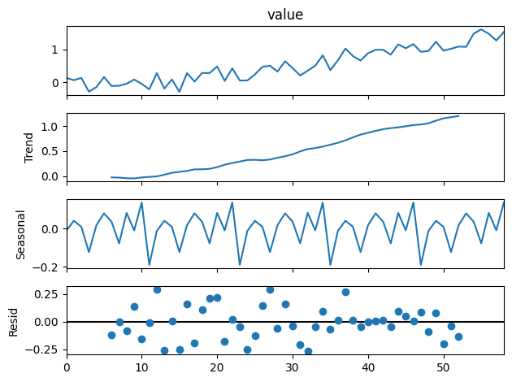

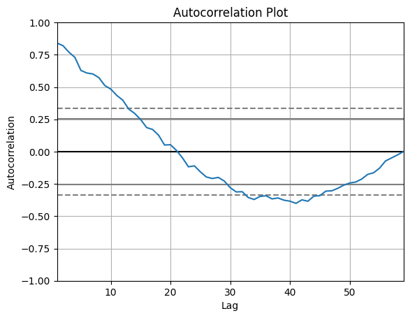

```python
#Seasonal Decomposition
def seasonal_decomposition(time_series):
    decomposition = seasonal_decompose(time_series['value'], model='additive', period=12)
    return decomposition

#Autocorrelation Plot
def plot_autocorrelation(time_series):
    pd.plotting.autocorrelation_plot(time_series['value'])
    plt.title('Autocorrelation Plot')
    plt.show()

#get global averages
tempss = world.drop(['area', 'months', 'element'], axis = 1).mean(axis=0)
#add to a dataframe
world_temps = pd.DataFrame(tempss, columns = ['value'])
world_temps = world_temps.reset_index()
world_temps.columns = ['date','value']
#overview
display(world_temps.head())
# Perform seasonal decomposition
decomposition_result = seasonal_decomposition(world_temps)

# Plot seasonal decomposition
decomposition_result.plot()
plt.show()

# Plot Autocorrelation
plot_autocorrelation(world_temps)
```

```python
#test for seasonality
import pymannkendall as mk
```

```python
%%time
def mann_kendall_seasonality_test_for_countries(dataframe, country_list):
    results = []

    for country in country_list:
        #get temperature change
        dataframe = dataframe[dataframe['Element'] =='Temperature change']
        #get monthly data
        dataframe = dataframe[dataframe.Months.isin(['January', 'February', 'March', 'April', 'May', 'June', 'July',
       'August', 'September', 'October', 'November', 'December'])]
        country_data = dataframe[dataframe['Area'] == country]['Value']


        # Calculate the Mann-Kendall test statistic and p-value
        res = mk.seasonal_test(country_data)

        # Get slope
        slope = res[6]

        # Determine the trend direction based on the p-value
        trend = res[0]

        # Append the results to the list of dictionaries
        results.append({'Country': country, 'Slope': slope, 'Trend': trend})

    # Create the DataFrame from the list of dictionaries
    results = pd.DataFrame(results)
    return results
```

```
CPU times: total: 0 ns
Wall time: 0 ns
```

```python
# Call the function
results_dataframe = mann_kendall_seasonality_test_for_countries(data2, data2.Area.unique())
```

```python
#get the top 5 countries that show a strong increasing seasonality trend
results_dataframe[results_dataframe['Trend'] == 'increasing'].sort_values('Slope', ascending = False).head(5)
```

|  | Country | Slope | Trend |
| --- | --- | --- | --- |
| 167 | Palestine | 295000.0 | increasing |
| 7 | Antarctica | 294999.0 | increasing |
| 124 | Libya | 294999.0 | increasing |
| 89 | Gibraltar | 294998.0 | increasing |
| 177 | Qatar | 294998.0 | increasing |

#### Are there any noticeable differences in temperature trends between developed and developing countries?

```python
developed, developing = data[data['area']=='Annex I countries'], data[data['area'] == 'Non-Annex I countries']
#get devloping data
developed = developed[developed['element'] =='Temperature change']
developed = developed[developed.months.isin(['January', 'February', 'March', 'April', 'May', 'June', 'July',
       'August', 'September', 'October', 'November', 'December'])]
#developing
developing = developing[developing['element'] =='Temperature change']
developing = developing[developing.months.isin(['January', 'February', 'March', 'April', 'May', 'June', 'July',
       'August', 'September', 'October', 'November', 'December'])]


#get temperature averages
developed_averages = developed.drop(['area', 'months', 'element'], axis = 1).mean(axis=0)
#developing
developing_averages = developing.drop(['area', 'months', 'element'], axis = 1).mean(axis=0)
```

```python
#plot the trends

# Create traces for Annex I and Non-Annex I countries
trace1 = go.Scatter(
    x=developed_averages.index,
    y=developed_averages.values,
    mode='lines+markers',
    name='Annex I countries',
    line=dict(color='blue', width=2),
    marker=dict(color='blue', size=8)
)

trace2 = go.Scatter(
    x=developing_averages.index,
    y=developing_averages.values,
    mode='lines+markers',
    name='Non-Annex I countries',
    line=dict(color='green', width=2),
    marker=dict(color='green', size=8)
)

# Create the layout for the plot
layout = go.Layout(
    title='Average Temperature Change Over the Years',
    xaxis_title='Year',
    yaxis_title='Average Temperature Change',
    showlegend=True,
    template='plotly_white'
)

# Create the figure and add the traces to it
fig = go.Figure(data=[trace1, trace2], layout=layout)

# Show the plot
fig.show()
```

[interactive chart not shown]

As shown in the plot above, historically, temperature change among developing countries surpassed that of developed countries (Annex 1 Countries) in *1964, 1969, 1976, 1982, 1985, and 1987. After 2010, developed nations had the highest temperature changes across all years up until 2019 indicating that overall, developed nations experience a higher temperature change compared to developing nations.

#### How does temperature change vary between different continents

We seek to determine the continent that has the highest temperature change in the past 2 decades. The continents in question include:

```python
continents = ['Asia', 'Africa', 'Northern America', 'South America', 'Antarctica', 'Europe', 'Australia']
continents = data[data.area.isin(continents)]

continents.area.unique()
```

```
array(['Antarctica', 'Australia', 'Africa', 'Northern America',
       'South America', 'Asia', 'Europe'], dtype=object)
```

```python
#get temperature change
continents = continents[continents['element'] =='Temperature change']
continents = continents[continents.months.isin(['January', 'February', 'March', 'April', 'May', 'June', 'July',
       'August', 'September', 'October', 'November', 'December'])]
continents = continents[['area','months','element','Y2000', 'Y2001', 'Y2002', 'Y2003', 'Y2004',
       'Y2005', 'Y2006', 'Y2007', 'Y2008', 'Y2009', 'Y2010', 'Y2011', 'Y2012',
       'Y2013', 'Y2014', 'Y2015', 'Y2016', 'Y2017', 'Y2018', 'Y2019']]
#data overview
continents.head()
```

|  | area | months | element | Y2000 | Y2001 | Y2002 | Y2003 | Y2004 | Y2005 | Y2006 | ... | Y2010 | Y2011 | Y2012 | Y2013 | Y2014 | Y2015 | Y2016 | Y2017 | Y2018 | Y2019 |
| --- | --- | --- | --- | --- | --- | --- | --- | --- | --- | --- | --- | --- | --- | --- | --- | --- | --- | --- | --- | --- | --- |
| 238 | Antarctica | January | Temperature change | -1.952 | -0.201 | 1.305 | 0.292 | 0.612 | 1.749 | 0.072 | ... | 2.022 | 1.525 | -0.224 | 1.402 | 0.942 | -0.914 | -1.637 | 0.488 | 0.757 | -0.509 |
| 240 | Antarctica | February | Temperature change | -1.781 | 0.840 | -0.195 | 0.709 | 1.628 | 0.470 | -1.302 | ... | 1.980 | 1.937 | 0.011 | -1.871 | -1.865 | -0.679 | -1.066 | 0.959 | 0.046 | 2.535 |
| 242 | Antarctica | March | Temperature change | -1.311 | -1.013 | 2.764 | 0.708 | -0.253 | 1.989 | -0.661 | ... | 2.779 | -0.917 | 1.480 | 1.626 | -2.003 | 0.423 | -0.341 | 1.931 | 1.858 | 1.966 |
| 244 | Antarctica | April | Temperature change | -2.791 | -1.726 | 2.972 | 0.245 | 1.556 | 1.247 | 0.934 | ... | -3.382 | -0.984 | -2.130 | -0.099 | 1.215 | 0.571 | 0.817 | -1.108 | -0.026 | 0.183 |
| 246 | Antarctica | May | Temperature change | -1.420 | 0.201 | 2.062 | -1.127 | -0.525 | -1.167 | 0.450 | ... | 2.507 | -2.658 | -0.475 | -3.115 | 2.165 | -1.133 | 1.219 | 1.268 | 3.549 | 0.086 |

5 rows × 23 columns

```python
#Compute average temperature change by region
average_changes = continents.drop(['months', 'element'], axis = 1).groupby('area').mean().mean(axis = 1)
#create dataframe
average_changes = pd.DataFrame(average_changes, columns = ['Average Temperature Change'])
average_changes = average_changes.sort_values('Average Temperature Change', ascending = False).reset_index()
# Create a bar chart for continents
fig = go.Figure()

fig.add_trace(go.Bar(
    x=average_changes['area'],
    y=average_changes['Average Temperature Change'],
    marker_color='steelblue',
    name='Average Temperature Change'
))

# Customize the layout
fig.update_layout(
    title='Average Temperature Change by Region',
    xaxis_title='Region',
    yaxis_title='Average Temperature Change',
    showlegend=True,
    template='plotly_white'
)

# Show the plot
fig.show()
```

[interactive chart not shown]

From the preceeding plot we observe that in the past 2 decades i.e., from 2000 to 2019, Europe had the highest average tempearture change (1.57) alongside *Northern America* (1.15), and *Asia* (1.06). Whereas Australia despite having experienced climate change effects such as heat surges and wilf forest fires had the second lowest temperature change over the same period (0.83) while Antarctica had the lowest temperature change (0.52).

#### What are the temperature variations in different regions of Africa in the last 2 decades?

```python
#get data related to different parts of Africa
africa = data[data.area.isin([
       'Eastern Africa', 'Middle Africa', 'Northern Africa',
       'Southern Africa', 'Western Africa'])]
#get temperature variation
africa = africa[africa['element'] =='Standard Deviation']
africa = africa[africa.months.isin(['January', 'February', 'March', 'April', 'May', 'June', 'July',
       'August', 'September', 'October', 'November', 'December'])]
africa = africa[['area','months','element','Y2000', 'Y2001', 'Y2002', 'Y2003', 'Y2004',
       'Y2005', 'Y2006', 'Y2007', 'Y2008', 'Y2009', 'Y2010', 'Y2011', 'Y2012',
       'Y2013', 'Y2014', 'Y2015', 'Y2016', 'Y2017', 'Y2018', 'Y2019']]
#data overview
africa.head()
```

|  | area | months | element | Y2000 | Y2001 | Y2002 | Y2003 | Y2004 | Y2005 | Y2006 | ... | Y2010 | Y2011 | Y2012 | Y2013 | Y2014 | Y2015 | Y2016 | Y2017 | Y2018 | Y2019 |
| --- | --- | --- | --- | --- | --- | --- | --- | --- | --- | --- | --- | --- | --- | --- | --- | --- | --- | --- | --- | --- | --- |
| 8467 | Eastern Africa | January | Standard Deviation | 0.345 | 0.345 | 0.345 | 0.345 | 0.345 | 0.345 | 0.345 | ... | 0.345 | 0.345 | 0.345 | 0.345 | 0.345 | 0.345 | 0.345 | 0.345 | 0.345 | 0.345 |
| 8469 | Eastern Africa | February | Standard Deviation | 0.338 | 0.338 | 0.338 | 0.338 | 0.338 | 0.338 | 0.338 | ... | 0.338 | 0.338 | 0.338 | 0.338 | 0.338 | 0.338 | 0.338 | 0.338 | 0.338 | 0.338 |
| 8471 | Eastern Africa | March | Standard Deviation | 0.363 | 0.363 | 0.363 | 0.363 | 0.363 | 0.363 | 0.363 | ... | 0.363 | 0.363 | 0.363 | 0.363 | 0.363 | 0.363 | 0.363 | 0.363 | 0.363 | 0.363 |
| 8473 | Eastern Africa | April | Standard Deviation | 0.399 | 0.399 | 0.399 | 0.399 | 0.399 | 0.399 | 0.399 | ... | 0.399 | 0.399 | 0.399 | 0.399 | 0.399 | 0.399 | 0.399 | 0.399 | 0.399 | 0.399 |
| 8475 | Eastern Africa | May | Standard Deviation | 0.451 | 0.451 | 0.451 | 0.451 | 0.451 | 0.451 | 0.451 | ... | 0.451 | 0.451 | 0.451 | 0.451 | 0.451 | 0.451 | 0.451 | 0.451 | 0.451 | 0.451 |

5 rows × 23 columns

```python
#Compute average standard deviation by region
average_variations = africa.drop(['months', 'element'], axis = 1).groupby('area').mean().mean(axis = 1)
#create dataframe
average_variations = pd.DataFrame(average_variations, columns = ['Average Standard Deviation'])
average_variations = average_variations.sort_values('Average Standard Deviation', ascending = False).reset_index()
average_variations
```

|  | area | Average Standard Deviation |
| --- | --- | --- |
| 0 | Southern Africa | 0.634500 |
| 1 | Western Africa | 0.552083 |
| 2 | Northern Africa | 0.532083 |
| 3 | Eastern Africa | 0.363833 |
| 4 | Middle Africa | 0.339250 |

```python
#get data related to different parts of Africa
africa = data[data.area.isin([
       'Eastern Africa', 'Middle Africa', 'Northern Africa',
       'Southern Africa', 'Western Africa'])]
#get temperature CHANGE
africa = africa[africa['element'] =='Temperature change']
africa = africa[africa.months.isin(['January', 'February', 'March', 'April', 'May', 'June', 'July',
       'August', 'September', 'October', 'November', 'December'])]
africa = africa[['area','months','element','Y2000', 'Y2001', 'Y2002', 'Y2003', 'Y2004',
       'Y2005', 'Y2006', 'Y2007', 'Y2008', 'Y2009', 'Y2010', 'Y2011', 'Y2012',
       'Y2013', 'Y2014', 'Y2015', 'Y2016', 'Y2017', 'Y2018', 'Y2019']]
#data overview
africa.head()
```

|  | area | months | element | Y2000 | Y2001 | Y2002 | Y2003 | Y2004 | Y2005 | Y2006 | ... | Y2010 | Y2011 | Y2012 | Y2013 | Y2014 | Y2015 | Y2016 | Y2017 | Y2018 | Y2019 |
| --- | --- | --- | --- | --- | --- | --- | --- | --- | --- | --- | --- | --- | --- | --- | --- | --- | --- | --- | --- | --- | --- |
| 8466 | Eastern Africa | January | Temperature change | 0.120 | 0.408 | 0.708 | 1.004 | 1.131 | 0.951 | 1.075 | ... | 1.259 | 0.856 | 0.556 | 1.184 | 0.967 | 0.787 | 1.442 | 1.262 | 0.668 | 1.303 |
| 8468 | Eastern Africa | February | Temperature change | 0.419 | 0.498 | 0.852 | 1.230 | 0.457 | 1.629 | 1.294 | ... | 1.274 | 0.777 | 0.838 | 1.198 | 0.699 | 1.375 | 1.443 | 1.163 | 1.178 | 1.245 |
| 8470 | Eastern Africa | March | Temperature change | 0.454 | 0.536 | 0.802 | 1.081 | 0.651 | 1.273 | 0.691 | ... | 0.988 | 0.674 | 0.960 | 0.974 | 1.005 | 1.509 | 2.469 | 1.114 | 0.843 | 1.503 |
| 8472 | Eastern Africa | April | Temperature change | 0.662 | 0.675 | 0.586 | 0.891 | 0.348 | 1.110 | 0.482 | ... | 1.215 | 1.502 | 0.409 | 0.730 | 0.766 | 0.880 | 1.084 | 1.112 | 0.420 | 2.017 |
| 8474 | Eastern Africa | May | Temperature change | 0.480 | 0.674 | 0.683 | 1.043 | 0.332 | 1.076 | 0.647 | ... | 1.736 | 1.234 | 0.984 | 0.798 | 1.093 | 1.284 | 0.503 | 1.299 | 0.851 | 1.799 |

5 rows × 23 columns

```python
#Compute average temperature change by region
average_changes = africa.drop(['months', 'element'], axis = 1).groupby('area').mean().mean(axis = 1)
#create dataframe
average_changes = pd.DataFrame(average_changes, columns = ['Average Temperature Change'])
average_changes = average_changes.sort_values('Average Temperature Change', ascending = False).reset_index()
average_changes
```

|  | area | Average Temperature Change |
| --- | --- | --- |
| 0 | Northern Africa | 1.213729 |
| 1 | Western Africa | 1.096808 |
| 2 | Eastern Africa | 0.956954 |
| 3 | Middle Africa | 0.867329 |
| 4 | Southern Africa | 0.837617 |

Overall, we note that Northern Africa and Western Africa recorded the highest average temperature change over the last 2 decades . On the other hand, Middle Africa and Southern Africa had the lowest average temperature change over the same period indicating that on average, while all the regions in Africa became hotter over the past 2 decades, Northern Africa and Western Africa experienced the highest temeprature change.

The goal is to determine whether the observed trend in the average temperature for a given country is increasing, decreasing, or constant. To this end, we use the Mann-Kendall Trend Test to determine whether or not a trend exists in time series data. It is a non-parametric test, implying that there is no underlying assumption made about the normality of the data (Shourov & Mahmud, 2019). However, it is important to check whether the data has autocorrelation in which case a modified Mann-Kendall Trend Test is used. The following hypothesis is tested at 0.05 level of confidence:

Test for trend The hypotheses for the test are as follows:

H0 (null hypothesis): There is no trend present in the data.

HA (alternative hypothesis): A trend is present in the data. (This could be a positive or negative trend)

```python
%%time
def mann_kendall_test_for_countries(dataframe, country_list):
    results = []

    for country in country_list:
        #get temperature change
        dataframe = dataframe[dataframe['Element'] =='Temperature change']
        #get monthly data
        dataframe = dataframe[dataframe.Months.isin(['January', 'February', 'March', 'April', 'May', 'June', 'July',
       'August', 'September', 'October', 'November', 'December'])]
        country_data = dataframe[dataframe['Area'] == country]['Value']


        # Calculate the Mann-Kendall test statistic and p-value
        res = mk.hamed_rao_modification_test(country_data)

        # Get slope
        slope = res[6]

        # Determine the trend direction based on the p-value
        trend = res[0]

        # Append the results to the list of dictionaries
        results.append({'Country': country, 'Slope': slope, 'Trend': trend})

    # Create the DataFrame from the list of dictionaries
    results = pd.DataFrame(results)
    return results


# Call the function
results_dataframe = mann_kendall_test_for_countries(data2, data2.Area.unique())
```

```
CPU times: total: 29.1 s
Wall time: 30.5 s
```

```python
#get the top 10 countries that show an increasing trend
results_dataframe[results_dataframe['Trend'] == 'increasing'].sort_values('Slope', ascending = False).head(10)
```

|  | Country | Slope | Trend |
| --- | --- | --- | --- |
| 187 | Saint Pierre and Miquelon | 2.183300e+08 | increasing |
| 146 | Morocco | 1.326540e+08 | increasing |
| 103 | India | 1.107974e+08 | increasing |
| 151 | Nepal | 8.906908e+07 | increasing |
| 17 | Bangladesh | 8.226491e+07 | increasing |
| 91 | Greenland | 6.726546e+07 | increasing |
| 222 | Tunisia | 6.293155e+07 | increasing |
| 123 | Liberia | 6.179582e+07 | increasing |
| 189 | Samoa | 5.926543e+07 | increasing |
| 197 | Sierra Leone | 5.200290e+07 | increasing |

### Recommendations

Based on the findings reported in the section above, the following recommendations are made:

#### Conclusion

While developed countries have historically contributed more to carbon emissions, the recent trend indicates that temperature change has increased significantly in these nations as well. This finding emphasizes the importance of continued efforts to reduce emissions and combat climate change on a global scale.

Overall, the results empasize the urgency of taking action to limit global temperature rise as an indicator of climate change and address the impacts of climate change. Implementing the recommended measures and fostering international cooperation are essential steps toward a sustainable and climate-resilient future.

### References

Brohan, P., Kennedy, J., Harris, I. & Tett, S., 2006. Uncertainty estimates in regional and global observed temperature changes: a new data set from 1850. J. Geophys. Res., 111(D12106), pp. 1-21.

England, M. R., Eisenman, I., Lutsko, N. J. & Wagner, T. J., 2021. The recent emergence of Arctic Amplification.. Geophys. Res. Lett., 48(2021).

Hansen, J., Ruedy, R., Sato, M. & Lo, K., 2010. Global surface temperature change. Rev. Geophys., 48(2010).

Hansen, J., Sato, M., Ruedy, R. & Nazarenko, L., 2005. Earth's energy imbalance: Confirmation and implications.. Science, 308(2005), pp. 1431-1435.

Holland, M. M. & Bitz, C. M., 2003. Polar amplification of climate change in coupled models. Clim. Dyn., 21(2003), pp. 221-223.

IEA, 2021. World Energy Outlook 2021. In: Special Report : Global Warming of 1.5°C. s.l.:IPCC.

IPCC, 2018. Special report on global warming of 1.5°C above pre-industrial levels and related global greenhouse gas emission pathways. [Online] Available at: https://www.ipcc.ch/sr15/ [Accessed 28 July 2023].

IPCC, 2021. Climate Change 2021: the Physical Science Basis. Contribution of Working Group I to the Sixth Assessment Report of the Intergovernmental Panel on Climate Change, s.l.: Cambridge University Press.

Karl, T., Melillo, J., Peterson, T. & Hassol, S., 2009. Global Climate Change Impacts in the United States. 1st ed. New York, NY, USA: Cambridge University Press.

Kortelainen, N. & Karhu, A., 2004. Regional and seasonal trends in the oxygen and hydrogen isotope ratios of Finnish groundwaters: a key for mean annual precipitation. J. Hydrol., 1(4), pp. 143-157.

OECD, 2023. Climate change, s.l.: OECD iLibrary.

Rahmstorf, S. & Coumou, D., 2011. Increase of extreme events in a warming world. Proc. Natl. Acad. Sci. U.S.A., 108(2011), pp. 17905-17909.

Serreze, M., Barrett, A., Stroeve, J. & Kindig, D., 2009. The emergence of surface-based Arctic amplification. Cryosphere, 3(2009), p. 11.

Serreze, M. C. & Francis, J. A., 2006. The Arctic amplification debate. Clim. Change, 76(2006), pp. 241-246.

Shepard, D., 2019. Global warming: severe consequences for Africa. [Online] Available at: https://www.un.org/africarenewal/magazine/december-2018-march-2019/global-warming-severe-consequences-africa [Accessed 28 July 2023].

World Meteorological Organization, 2022. State of Climate in Africa highlights water stress and hazards, s.l.: World Meteorological Organization.

```python
#!pip install ipython --user
```

```python
import io
import os
from nbformat import current

count_words_markdown = 0
count_words_heading = 0
count_words_code = 0

for root, dirs, files in os.walk("."):
    for file in files:
        if file.endswith("Data Exploration.ipynb") and not file.endswith("checkpoint.ipynb") :
            #print(os.path.join(root, file))
            with io.open(os.path.join(root, file), 'r', encoding='utf-8') as f:
                nb = current.read(f, 'json')

            word_count_markdown = 0
            word_count_heading = 0
            word_count_code = 0
            for cell in nb.worksheets[0].cells:
                if cell.cell_type == "markdown":
                    word_count_markdown += len(cell['source'].replace('#', '').lstrip().split(' '))
                elif cell.cell_type == "heading":
                    word_count_heading += len(cell['source'].replace('#', '').lstrip().split(' '))
                elif cell.cell_type == "code":
                    word_count_code += len(cell['input'].replace('#', '').lstrip().split(' '))
            count_words_markdown += word_count_markdown
            count_words_heading += word_count_heading
            count_words_code += word_count_code

print("There are {} Words in the reports' markdown" .format(count_words_markdown))
print("Total word count in the report excluding the codes is {} " .format(count_words_markdown + count_words_heading))
```

```
There are 3058 Words in the reports' markdown
Total word count in the report excluding the codes is 3063
```